# Statistika NBA igrača od 1950. godine

Preko 3000 igrača kroz 67 sezona i preko 50 varijabli po igraču

Ante Gazibarić, Antun Magdić, Ante Žužul

21.5.2019.

Poznato je kako je visina jedan od bitnih čimbenika uspjeha igrača u košarci. Najniži igrači igraju poziciju guard, a u prosjeku su visoki 189 cm. Za ostale pozicije igrači moraju biti još viši. Iz podataka se može zaključiti kako su igrači koji osim pozicije guard igraju i poziciju forward značajno viši od igrača koji igraju samo poziciju guard. Za ostale pozicije moguće je doći do sličnih zaključaka, a igrači koji igraju poziciju centar (najviši) u prosjeku su visoki čak 211 cm.

```r
# Compare guards ("G") and forward guards ("F-G")
guards = players[players$position == "G" , ]
fguards = players[players$position == "F-G" | players$position == "G-F", ]
centers = players[players$position == "C", ]
mean(guards$height)
```

```
## [1] 189.3469
```

```r
mean(fguards$height)
```

```
## [1] 195.5756
```

```r
mean(centers$height)
```

```
## [1] 211.326
```

```r
t.test(guards$height, fguards$height, alt = "less", var.equal = TRUE)
```

```
##
##  Two Sample t-test
##
## data:  guards$height and fguards$height
## t = -22.497, df = 2149, p-value < 2.2e-16
## alternative hypothesis: true difference in means is less than 0
## 95 percent confidence interval:
##       -Inf -5.773058
## sample estimates:
## mean of x mean of y
##  189.3469  195.5756
```

U ligi NBA igra i nezanemariv broj igrača iz Europe. Iz podataka je moguće uočiti kako su Europljani u prosjeku viši od ostalih igrača. Ovdje bi bilo pogrešno zaključiti da su Europljani općenito viši od od neeuropljana. Podaci su vjerojatno takvi jer se prilikom izbora igrača koji će igrati u ligi NBA više traži od Europljana (ako su neki igrač iz Amerike i neki igrač iz Europe jednako dobri, igrač iz Amerike će vjerojatno biti izabran).

```r
# Statistics between European players and other
europeans = players2[players2$birth_state %in% europeanCountries$name, ]
other = setdiff(players2, europeans)
t.test(europeans$height, other$height, alt="two.sided")
```

```
##
##  Welch Two Sample t-test
##
## data:  europeans$height and other$height
## t = 12.386, df = 209.59, p-value < 2.2e-16
## alternative hypothesis: true difference in means is not equal to 0
## 95 percent confidence interval:
##  6.864229 9.462768
## sample estimates:
## mean of x mean of y
##  206.8684  198.7049
```

Iz sljedećeg testa o proporciji moguće je vidjeti da Europljani u prosjeku bolje gađaju (i iz igre, a i slobodna bacanja). Isto kao i u prethodnom primjeru vjerojatno se ne radi o superiornosti Europljana. Razlog ovome je nešto teži standard koji Europljani moraju zadovoljiti da bi igrali u ligi NBA.

```r
europeanStats = seasonsStats[seasonsStats$Player %in% europeans$Player, ]
otherStats = seasonsStats[seasonsStats$Player %in% other$Player, ]

playerFTA = c(sum(europeanStats$FTA), sum(otherStats$FTA))
playerFT = c(sum(europeanStats$FT), sum(otherStats$FT))

prop.test(playerFT, playerFTA, alternative="t", correct="FALSE")
```

```
##
##  2-sample test for equality of proportions without continuity
##  correction
##
## data:  playerFT out of playerFTA
## X-squared = 221.3, df = 1, p-value < 2.2e-16
## alternative hypothesis: two.sided
## 95 percent confidence interval:
##  0.01641726 0.02126395
## sample estimates:
##    prop 1    prop 2
## 0.7655877 0.7467471
```

```r
playerFGA = c(sum(europeanStats$FGA), sum(otherStats$FGA))
playerFG = c(sum(europeanStats$FG), sum(otherStats$FG))

prop.test(playerFG, playerFGA, alternative="t", correct="FALSE")
```

```
##
##  2-sample test for equality of proportions without continuity
##  correction
##
## data:  playerFG out of playerFGA
## X-squared = 761.87, df = 1, p-value < 2.2e-16
## alternative hypothesis: two.sided
## 95 percent confidence interval:
##  0.02048130 0.02362254
## sample estimates:
##    prop 1    prop 2
## 0.4731653 0.4511134
```

Na ljedeća dva grafa prikazana je ovisnost broja pokušaja trica o uspješnosti igrača u tricama. Moguće je uočiti slabu korelaciju između ove dvije varijable. Igrači koji bolje pucaju zbog toga će pucati i češće. Međutim obrambeni igrači na njih više i paze pa zato veza nije očitija.

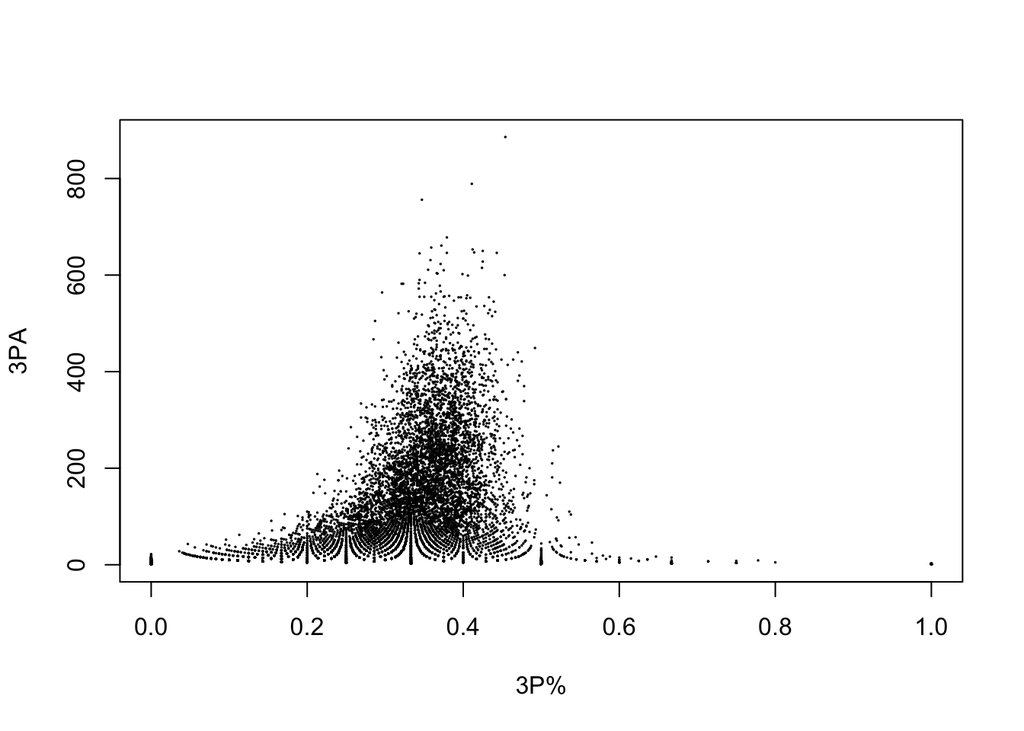

```r
plot(seasonsStats$X3P., seasonsStats$X3PA, cex=0.1, xlab="3P%", ylab="3PA")
```

```r
cor(seasonsStats$X3P.[!is.na(seasonsStats$X3P.) & !is.na(seasonsStats$X3PA)], seasonsStats$X3PA[!is.na(seasonsStats$X3P.) & !is.na(seasonsStats$X3PA)], method="pearson")
```

```
## [1] 0.4096447
```

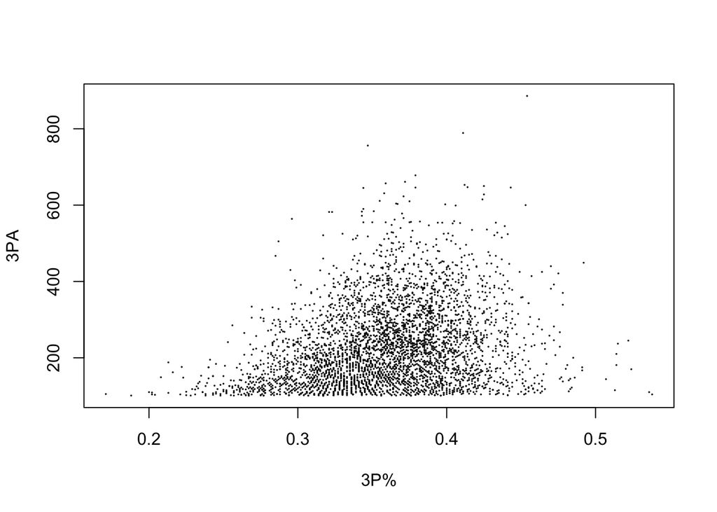

```r
plot(seasonsStats$X3P.[seasonsStats$X3PA > 100], seasonsStats$X3PA[seasonsStats$X3PA > 100], cex=0.1, xlab="3P%", ylab="3PA")
```

Sljedeća dva grafa vezana su uz dobnu strukturu lige NBA. Prvi graf prikazuje dobnu raspodjelu igrača. Sa starenjem igrači sve češće prestaju igrati u ligi NBA jer više ne zadovoljavaju kriterije koji su potrebni da bi igrač mogao igrati u ligi. Ali zato oni koji ostaju u ligi igraju u prosjeku jednako dobro kao i svi ostali. Drugi graf prikazuje omjer zabijenih i promašenih šuteva igrača određene starosti. Taj je prosjek za sve gotovo starosti približno jednak.

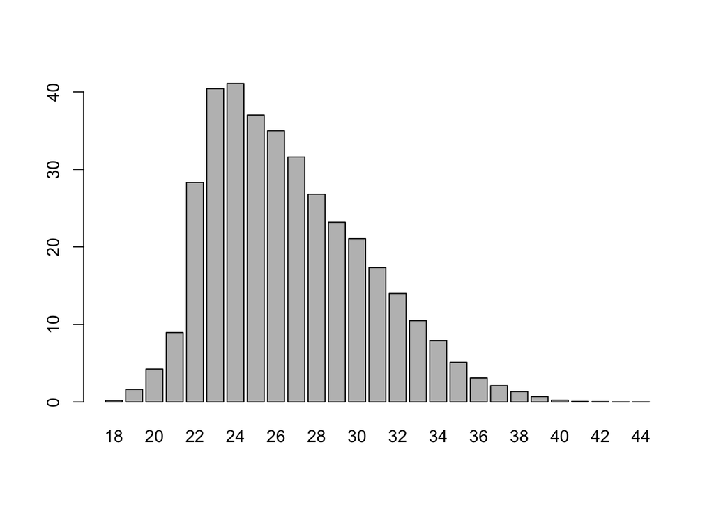

```r
ages <- min(seasonsStats$Age, na.rm=TRUE):max(seasonsStats$Age, na.rm=TRUE)
values <- rep(0, length(ages))
avg <- rep(0, length(ages))
for (i in 1:length(ages)) {
  age = ages[i]
  values[i] <- length(seasonsStats$Age[!is.na(seasonsStats$Age) & seasonsStats$Age == age])
  avg[i] <- sum(seasonsStats$FG[!is.na(seasonsStats$Age) & seasonsStats$Age == age]) / sum(seasonsStats$FGA[!is.na(seasonsStats$Age) & seasonsStats$Age == age])
}
values <- values / length(unique(ss$Year))
barplot(setNames(values, ages))
```

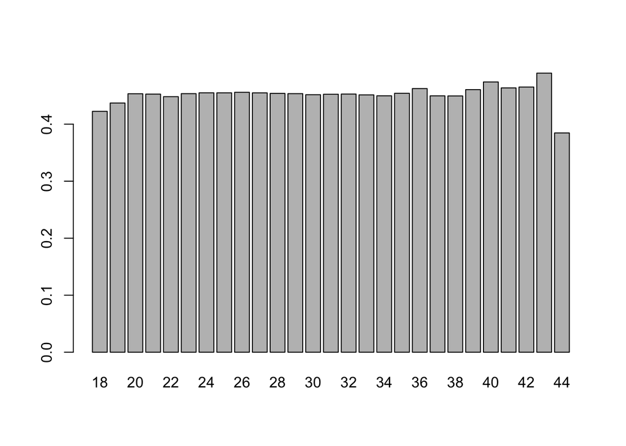

```r
barplot(setNames(avg, ages))
```

```r
colleges = unique(players$college)
colleges = droplevels.factor(colleges, "")
nHeights = 40
en = new.env()
for(i in seq(length(colleges))) {
  college = as.character(colleges[i])
  heights = players[as.character(players$college) == college, "height"]
  heights = heights[!is.na(heights)]
  if (length(heights) <= nHeights) next

  en[[as.character(college)]] = heights
}


allHeightValues = numeric()
collegeValues = character()
for (v in ls(en)) {
    a = en[[v]]
    allHeightValues = c(allHeightValues, a)
    collegeValues = c(collegeValues, rep(v, c(length(a))))
}

anovaModel = lm(allHeightValues ~ collegeValues)
anova(anovaModel)
```

```
## Analysis of Variance Table
##
## Response: allHeightValues
##                 Df Sum Sq Mean Sq F value  Pr(>F)
## collegeValues   17   2280 134.124  1.7037 0.03671 *
## Residuals     1031  81168  78.728
## ---
## Signif. codes:  0 '***' 0.001 '**' 0.01 '*' 0.05 '.' 0.1 ' ' 1
```

Nakon uvođenja trice 1979. godine nije odmah bilo jasno koliko je to vrijedan dodatak igri. Ekipe su to s vremenom počele shvaćati (između ostaloga i zbog sve veće primjene statističkih metoda u ligi) i tako se iz godine u godinu puca sve više trica. Ovisnost broja pokušanih trica o godini je gotovo linearna i prikazana je u sljedećem grafu.

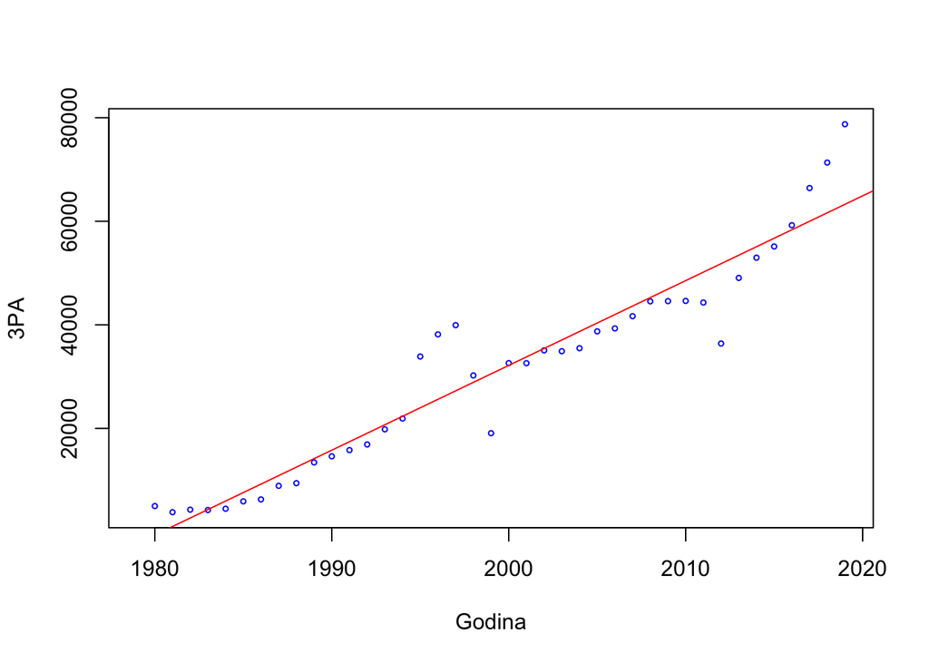

```r
years <- 1979:2019
threes <- rep(0, length(years))
for (i in 1:length(years)) {
  threes[i] <- sum(teams$X3PA[teams$Year == years[i]])
}

lm.r <- lm(threes ~ years)

plot(years, threes, cex=0.5, xlab="Godina", ylab="3PA", col="blue")
abline(lm.r, col="red")
```

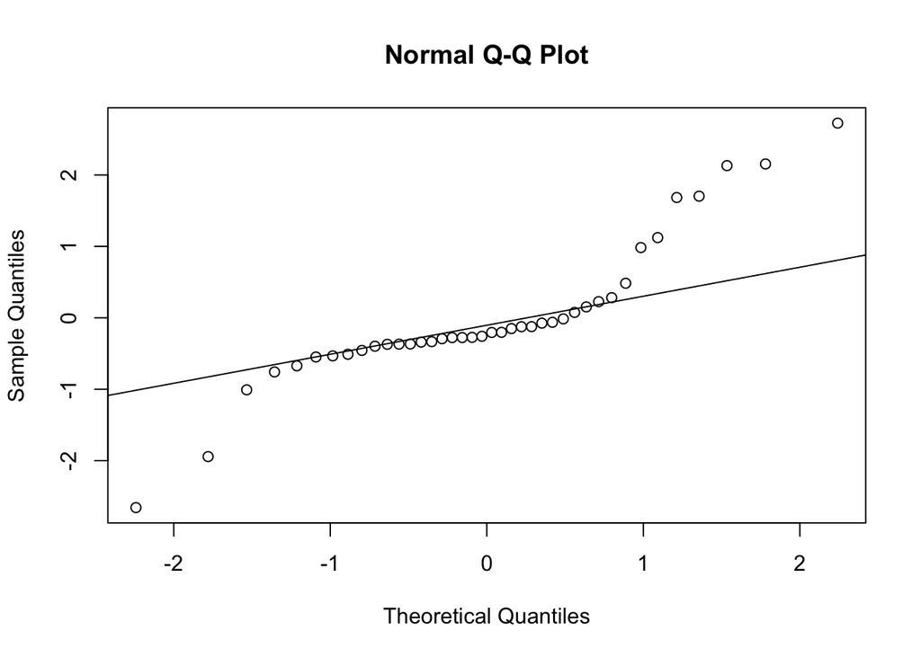

```r
qqnorm(rstandard(lm.r))
qqline(rstandard(lm.r))
```

Postavlja se pitanje jesu li trice stvarno korisne za ishod utakmica. Sljedeći graf prikazuje korelaciju postotka pogođenih trica neke ekipe i broja pobjeda te ekipe kroz godine od uvođenja trice. Iz grafa se vidi da uspješnost u pucanju trica postaje sve važnija za uspjeh ekipe. Pearsonov koeficijent korelacije prikazan je plavom linijom, a Spearmanov crvenom.

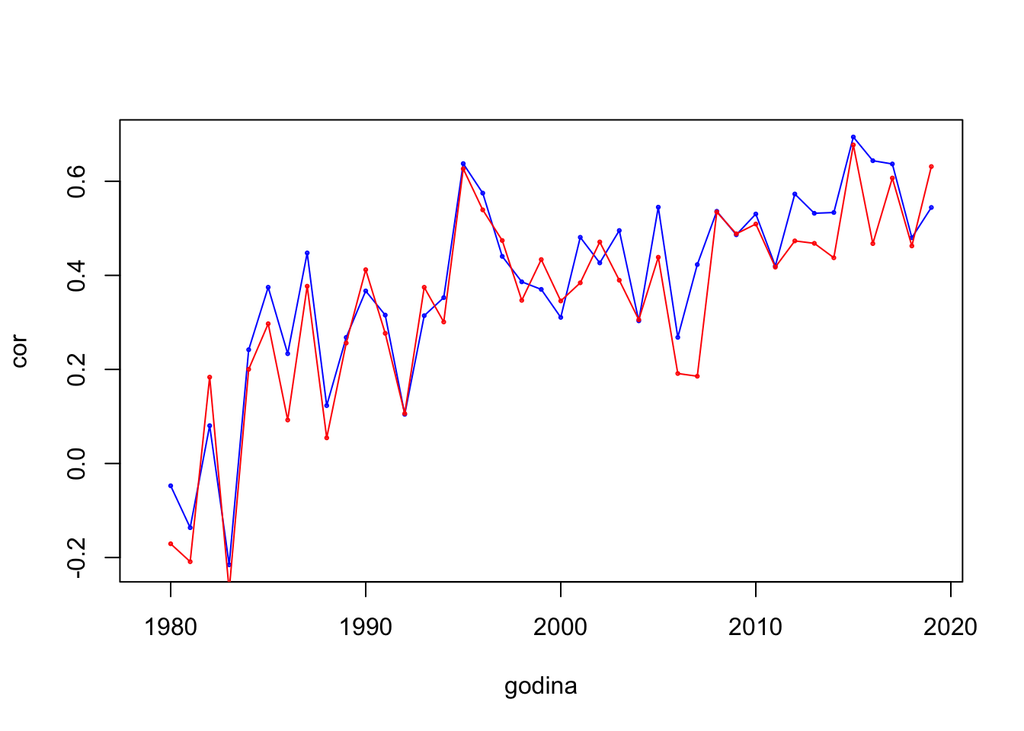

```r
years <- 1979:2019
correlationsPearson <- rep(0, length(years))
correlationsSpearman <- rep(0, length(years))
for (i in 1:length(years)) {
  yearStats <- teams[teams$Year == years[i], ]
  correlationsPearson[i] <- cor(yearStats$X3P / yearStats$X3PA, yearStats$W, method="pearson")
  correlationsSpearman[i] <- cor(yearStats$X3P / yearStats$X3PA, yearStats$W, method="spearman")
}
plot(years, correlationsPearson, cex=0.3, col="blue", xlab="godina", ylab="cor")
lines(years, correlationsPearson, col="blue")
points(years, correlationsSpearman, cex=0.3, col="red")
lines(years, correlationsSpearman, col="red")
```

Na sljedećem grafu crvena linija prikazuje najveći broj pobjeda u sezoni, plava najmanji broj pobjeda potreban za ulazak u doigravanje, a crna linija prikazuje najmanji broj pobjeda u sezoni općenito. U većini sezona igra se ukupno 82 utakmice, a u 1998./1999. odigrano ih je samo 50, a u 2012. samo 66. Kroz vrijeme se vrijednosti značajno ne mijenjaju. 1999 ima samo 50 utakmica, a 2012 66.

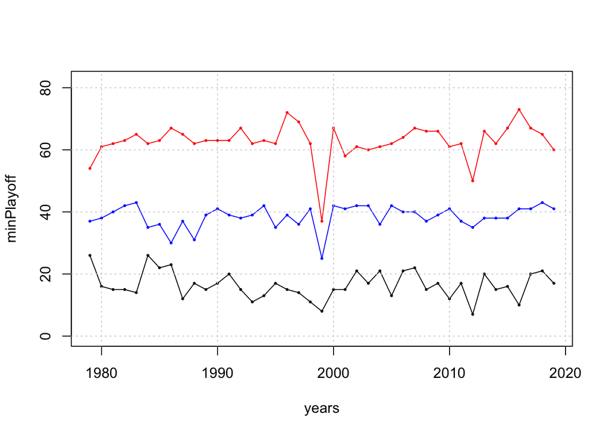

```r
years <- 1979:2019
minPlayoff <- rep(0, length(years))
maxWins <- rep(0, length(years))
minWins <- rep(0, length(years))
for (i in 1:length(years)) {
  minPlayoff[i] <- min(teams$W[teams$Year == years[i] & teams$PO])
  maxWins[i] <- max(teams$W[teams$Year == years[i]])
  minWins[i] <- min(teams$W[teams$Year == years[i]])
}
plot(years, minPlayoff, cex=0.3, col="blue", ylim=c(0, 82))
lines(years, minPlayoff, col="blue")
points(years, maxWins, cex=0.3, col="red")
lines(years, maxWins, col="red")
points(years, minWins, cex=0.3)
lines(years, minWins)
grid()
```

Liga NBA podijeljena je na dvije konferencije: istočnu i zapadnu. Često se vode debate o tome koja je konferencija jača i zapadna konferencija u pravilu se smatra jačom. U sljedećem grafu crvenom linijom prikazan je najmanji broj pobjeda potreban za ulazak u doigravanje u zapadnoj konferenciji, a plavom linijom najmanji broj pobjeda potreban za ulazak u doigravanje u istočnoj konferenciji. Može se uočiti da je u zapadnoj konferenciji stvarno u prosjeku potreban veći broj pobjeda za doigravanje. To potvrđuje i provedeni t test, iako njega u ovom slučaju ne treba shvatiti previše ozbiljno budući da varijable nad kojima je test proveden nisu nezavisne.

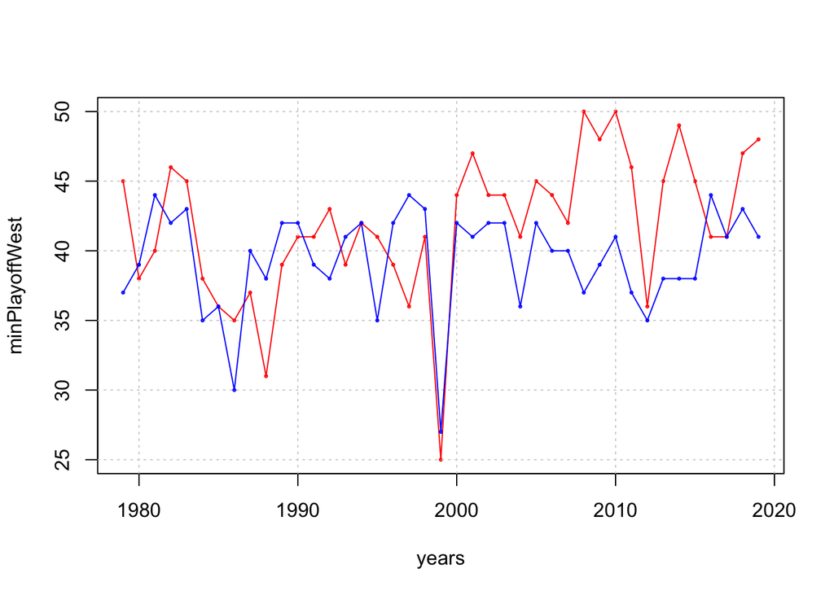

```r
isWestern <- function(abbr) {
  if (length(abbr) == 1) {
    return(as.character(teamData[as.character(abbr) == as.character(teamData$Abbr), ]$Conf) == "W")
  }
  isWesternV <- rep(FALSE, length(abbr))
  for (i in 1:length(abbr)) {
    isWesternV[i] <- isWestern(abbr[i])
  }
  return(isWesternV)
}
tms <- teams[teams$Year >= 1979, ]
western <- isWestern(tms$Tm)
tms <- cbind(tms, western)
years <- 1979:2019
minPlayoffWest <- rep(0, length(years))
minPlayoffEast <- rep(0, length(years))
for (i in 1:length(years)) {
  minPlayoffWest[i] <- min(tms$W[tms$Year == years[i] & tms$western & tms$PO])
  minPlayoffEast[i] <- min(tms$W[tms$Year == years[i] & !tms$western & tms$PO])
}
plot(years, minPlayoffWest, cex=0.3, col="red")
grid()
lines(years, minPlayoffWest, col="red")
points(years, minPlayoffEast, cex=0.3, col="blue")
lines(years, minPlayoffEast, col="blue")
```

```r
t.test(minPlayoffEast, minPlayoffWest, alternative="less")
```

```
##
##  Welch Two Sample t-test
##
## data:  minPlayoffEast and minPlayoffWest
## t = -2.4587, df = 72.038, p-value = 0.008174
## alternative hypothesis: true difference in means is less than 0
## 95 percent confidence interval:
##        -Inf -0.7782081
## sample estimates:
## mean of x mean of y
##  39.41463  41.82927
```

Sljedeći graf prikazuje razliku potrebnih pobjeda za doigravanje između zapadne i istočne konferencije. Ako je više pobjeda bilo potrebno na zapadu, vrijednosti su pozitivne (crvene točke), a ako je na istoku bilo lakše izboriti doigravanje vrijednsoti su negativne (plave točke). Ovdje je još jače izraženo da je zapadna konferencija stvarno teža, odnosno jača.

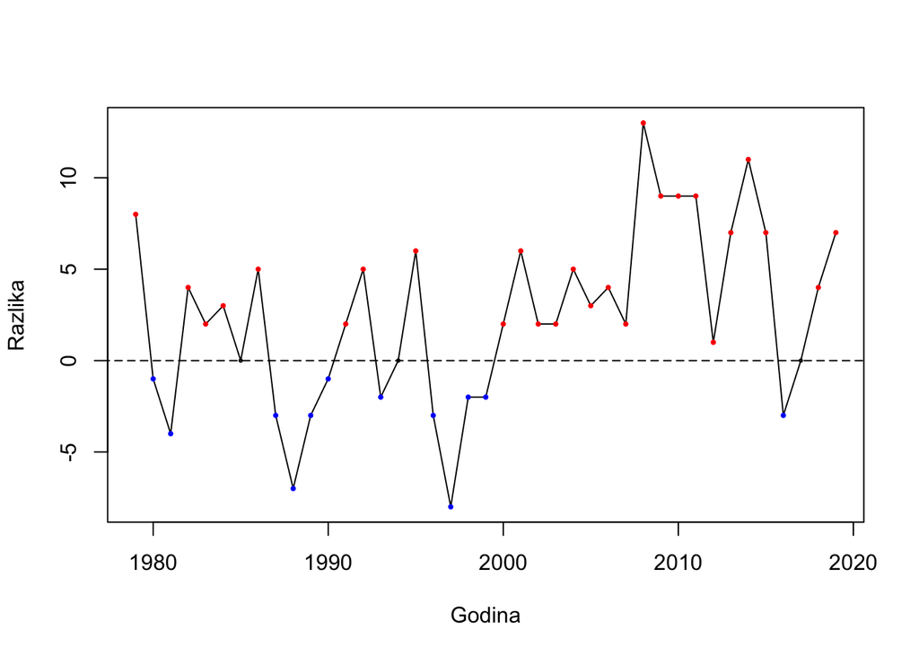

```r
diff <- minPlayoffWest - minPlayoffEast
plot(years, diff, cex=0.3, xlab="Godina", ylab="Razlika")
lines(c(0, 10000), c(0, 0), lty="43")
lines(years, diff)
for(i in 1:length(diff)) {
  current <- diff[i]
  if (current > 0)  {
    points(years[i], diff[i], cex=0.4, col="red")
    points(years[i], diff[i], cex=0.2, col="red")
  } else if (current < 0) {
    points(years[i], diff[i], cex=0.2, col="blue")
    points(years[i], diff[i], cex=0.4, col="blue")
  }
}
```

Sljedeći graf prikazuje ukupni broj pobjeda ekipa zapadne (crvena linija), odnosno istočne (plava linija) konferencije kroz godine. Ekipe sa zapada uglavnom imaju više pobjeda.

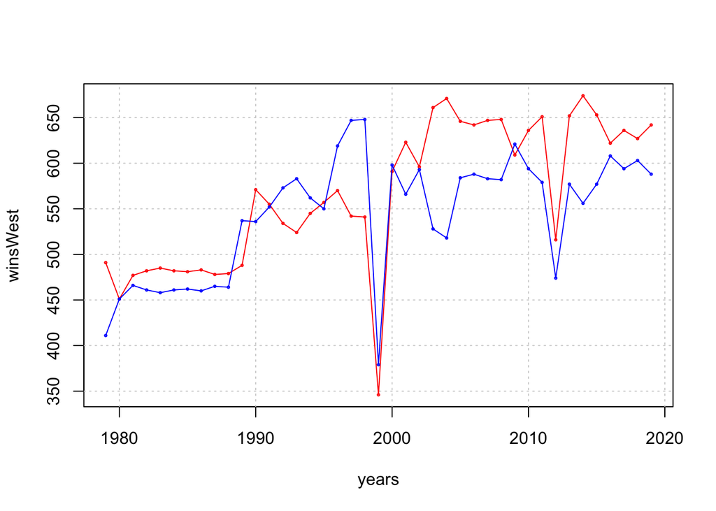

```r
winsWest <- rep(0, length(years))
winsEast <- rep(0, length(years))
for (i in 1:length(years)) {
  winsEast[i] <- sum(tms$W[tms$Year == years[i] & !tms$western])
  winsWest[i] <- sum(tms$W[tms$Year == years[i] & tms$western])
}

plot(years, winsWest, cex=0.3, col="red")
grid()
lines(years, winsWest, col="red")
points(years, winsEast, cex=0.3, col="blue")
lines(years, winsEast, col="blue")
```

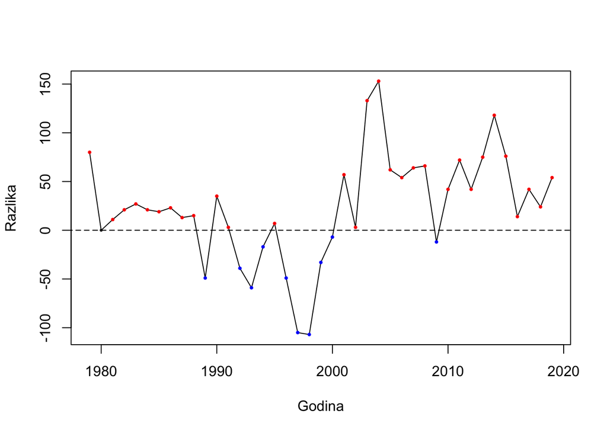

```r
diff <- winsWest - winsEast
plot(years, diff, cex=0.3, xlab="Godina", ylab="Razlika")
lines(c(0, 10000), c(0, 0), lty="43")
lines(years, diff)
for(i in 1:length(diff)) {
  current <- diff[i]
  if (current > 0)  {
    points(years[i], diff[i], cex=0.4, col="red")
    points(years[i], diff[i], cex=0.2, col="red")
  } else if (current < 0) {
    points(years[i], diff[i], cex=0.2, col="blue")
    points(years[i], diff[i], cex=0.4, col="blue")
  }
}
```

Budući da ulazak u doigravanje ne ovisi samo o broju pobjeda pojedine ekipe, već o cjelokupnom stanju lige (broja pobjeda svih ekipa) zanimljivo je vidjeti koliko pobjeda u pravilu ekipa treba ostvariti u sezoni kako bi izborila doigravanje. Sljedeći graf prikazuje ulazak u doigravanje u ovisnosti o broju pobjeda (ulazak u doigravanje na osi y označen je jedinicom, a ne ulazak nulom). Provedena je logistička regresija. Vidi se da je u nekim slučajevima bilo potrebno samo 25 pobjeda za ulazak u doigravanje, dok nekada ni 48 utakmica nije bilo dovoljno (iako je predikcija za 48 pobjeda 0.97, odnosno gotovo siguran ulazak u doigravanje).

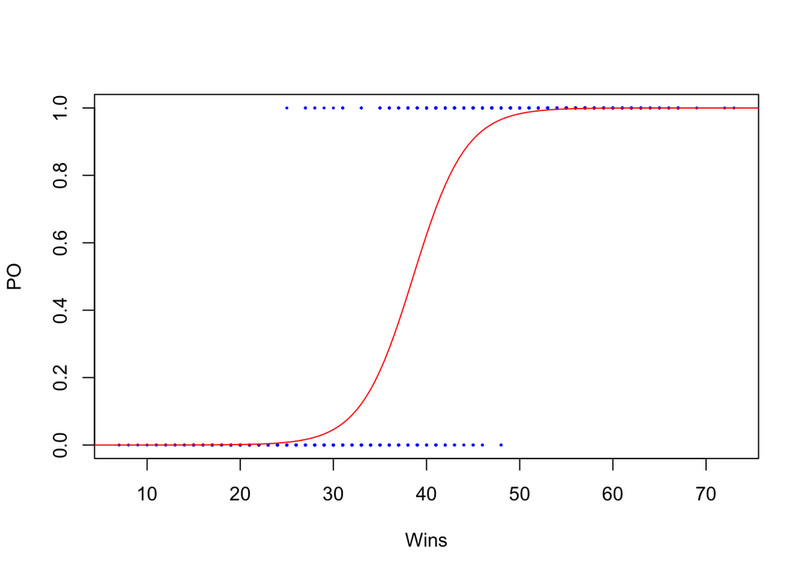

```r
# Broj pobjeda / Ulazak u doigravanje
ta <- teams[teams$Year >= 1979, ]
po <- rep(0, length(ta$PO))
for (i in 1:length(ta$PO)) {
  if (ta$PO[i]) {
    po[i] <- 1
  }
}

myData <- data.frame(cbind(ta$W, po))
names(myData) <- c("Wins", "PO")
logreg <- glm(PO ~ Wins, data=myData, family=binomial())
xWins <- seq(1, 82, 0.5)
prediction <- predict(logreg, data.frame(Wins=xWins), type="response")
plot(ta$W, po, cex=0.2, xlab="Wins", ylab="PO", col="blue")
lines(xWins, prediction, cex=0.1, col="red")
```

```r
summary(logreg)
```

```
##
## Call:
## glm(formula = PO ~ Wins, family = binomial(), data = myData)
##
## Deviance Residuals:
##      Min        1Q    Median        3Q       Max
## -2.59780  -0.21628   0.03796   0.30148   3.10305
##
## Coefficients:
##              Estimate Std. Error z value Pr(>|z|)
## (Intercept) -13.66038    0.91688  -14.90   <2e-16 ***
## Wins          0.35416    0.02321   15.26   <2e-16 ***
## ---
## Signif. codes:  0 '***' 0.001 '**' 0.01 '*' 0.05 '.' 0.1 ' ' 1
##
## (Dispersion parameter for binomial family taken to be 1)
##
##     Null deviance: 1541.98  on 1125  degrees of freedom
## Residual deviance:  527.63  on 1124  degrees of freedom
## AIC: 531.63
##
## Number of Fisher Scoring iterations: 7
```

```r
print("Value for 48 wins:")
```

```
## [1] "Value for 48 wins:"
```

```r
print(predict(logreg, data.frame(Wins=c(48)), type="response")[[1]])
```

```
## [1] 0.9657576
```

```r
playerPlayoffs <- read.csv(file="data/player_playoff.csv", header=TRUE, sep=",")

avgBlocksSeason <- playerSeasons$BLK / playerSeasons$G
avgBlocksPlayoffs <- playerPlayoffs$BLK / playerPlayoffs$G

t.test(avgBlocksSeason, avgBlocksPlayoffs, alt = "two.sided", var.equal = TRUE)
```

```
##
##  Two Sample t-test
##
## data:  avgBlocksSeason and avgBlocksPlayoffs
## t = -0.49859, df = 26948, p-value = 0.6181
## alternative hypothesis: true difference in means is not equal to 0
## 95 percent confidence interval:
##  -0.01791186  0.01064715
## sample estimates:
## mean of x mean of y
## 0.4279199 0.4315522
```

```r
avgFoulsSeason <- playerSeasons$PF / playerSeasons$G
avgFoulsPlayoffs <- playerPlayoffs$PF / playerPlayoffs$G

t.test(avgFoulsSeason, avgFoulsPlayoffs, alt = "less", var.equal = TRUE)
```

```
##
##  Two Sample t-test
##
## data:  avgFoulsSeason and avgFoulsPlayoffs
## t = -17.003, df = 33914, p-value < 2.2e-16
## alternative hypothesis: true difference in means is less than 0
## 95 percent confidence interval:
##       -Inf -0.186697
## sample estimates:
## mean of x mean of y
##  2.088300  2.294994
```

```r
playerSeasonsTmp <- playerSeasons[!is.na(playerSeasons$FG.) & !is.na(playerSeasons$Age) & playerSeasons$Age > 18 & playerSeasons$Age < 41, ]
FGP = rep('šut lošiji od 45%', length(playerSeasonsTmp$FG.))
for (i in 1:length(playerSeasonsTmp$FG.)) {
  if (playerSeasonsTmp$FG.[i] > 0.45) {
    FGP[i] <- 'šut bolji od 45%'
  }
}

tbl = table(FGP, playerSeasonsTmp$Age)
tbl
```

```
##
## FGP                   19   20   21   22   23   24   25   26   27   28   29
##   šut bolji od 45%    50  141  259  726 1067 1099 1064  977  896  774  674
##   šut lošiji od 45%   79  190  385 1212 1600 1537 1306 1195 1024  879  787
##
## FGP                   30   31   32   33   34   35   36   37   38   39   40
##   šut bolji od 45%   575  445  374  257  182  119   98   38   25   17    9
##   šut lošiji od 45%  691  590  464  380  262  175  102   90   58   27   10
```

```r
chisq.test(tbl,correct=F)
```

```
##
##  Pearson's Chi-squared test
##
## data:  tbl
## X-squared = 97.517, df = 21, p-value = 7.912e-12
```